# **Visualización con ggplot2**

### *Introducción*

En ésta lección te enseñaremos a visualizar datos usando ggplot2. ¿Qué es ggplot2?, ggplot2 es un sistema que implementa una gramática gráfica, esto lo hace ser un sistema coherente para describir y construir graficas con mayor facilidad.

Para iniciar el curso, requerimos el uso de la libreria tidyverse, la cual se puede inicializar con el siguiente codigo: >library(tidyverse)

Iniciaremos por plantear una cuestión: ¿los autos con grandes engranes usan mas combustible que autos con engranes pequeños?

Para resolver esta pregunta, iniciaremos por imprimir los contenidos de un “data frame” correspondiente a las observaciones recolectadas por la agencia de protección del medio ambiente de U.S.A. en 38 modelos de autos.

> Data frame: Colección rectangular de variables en las columnas, y observaciones en los campos.

Imprime el data frame ingresando el comando: >mpg

Para obtener una descripción sobre los datos, variables, e información relevante para la interpretación correcta del data frame puedes usar ?mpg

Usar un ? antes de cualquier función o variable te permite obtener información importante para su comprensión, implementación o interpretación.

La cual, al reemplazar la información en mayusculas de la siguiente forma:

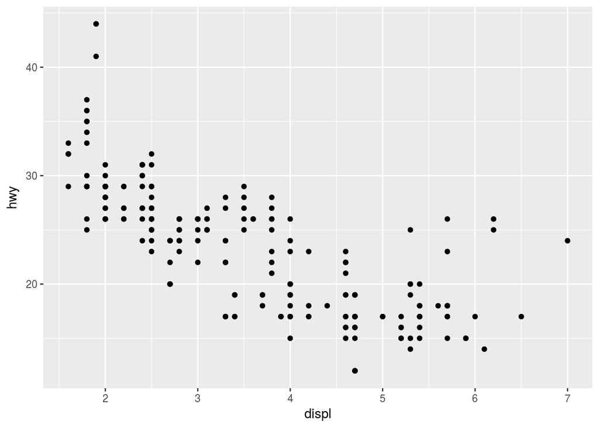

```r
library(ggplot2)
ggplot(data = mpg) + geom_point(mapping = aes(x = displ, y = hwy))
```

Donde: * ggplot: función que inicializa el conjunto de datos a usar * mpg: conjunto de datos a usar, en este caso un data frame * geom_point: función que genera una sección de un producto cartesiano por puntos * aes: contracción del termino aesthetics, los cuales son indicaciónes de gráficos insertados en el producto cartesiano, donde se definen variables y como se desea iterpretar visualmente, por ejemplo , donde se indica que dentro de los vectores x y y se insertaran los valores de las variables displ y hwy correspondientes a mpg

### *Mapeos Estéticos*

Al diagrama de dispersión binomial generado por el comando anterior, puede agregarle una tercera variable, como clase, asignándolo a una estética.

> *Estética: propiedad visual de los objetos en la gráfica*

La estetica incluye cosas como el tamaño, la forma o el color de tus datos en la gráfica; para hacer referencia a la estetica propiamente dicha utilizaremos la referencia nivel.

La función junta cada uno de los mapeos estéticos usados por capas y los pasa a el argumento de mapeo de capas. Incluso las variables x y y son esteticas al ser localizaciones que se pueden mapear como propiedades visuales sobre los datos.

Para poder realizar un mapeo mucho más sencillo de la clase de tus datos, asignaremos la variable color al código anterior, quedando como se muestra a continuación:

```r
library(tidyverse)
```

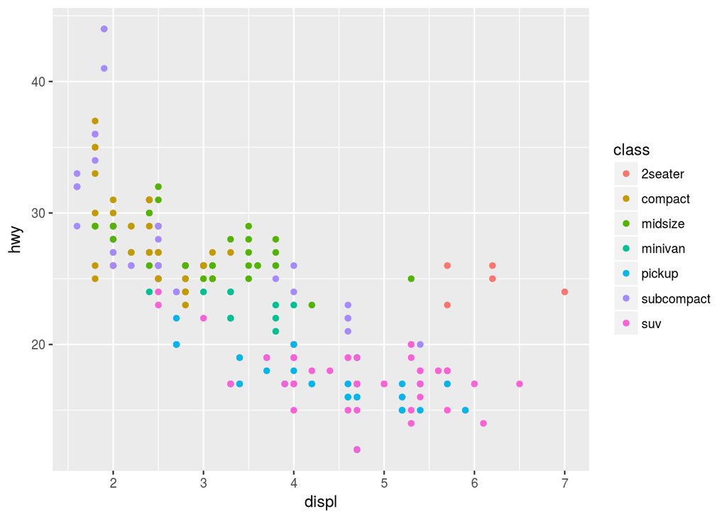

```r
ggplot(data = mpg) + geom_point(mapping = aes(x = displ, y = hwy, color = class))
```

Para asignar una estética a una variable, asocie el nombre de la estetica a la variable dentro del siguiente comando:

> aes().ggplot2

Automaticamente asignara un unico nivel a la estética(sólo en ésta parte un unico color) para cada valor único de la variable, un proceso conocido como:

> scaling.ggplot2

Este proceso tambien te agregará una leyenda que explica que niveles coresponden a cada valor.

También se puede hacer un mapeo por el tamaño de la clase, agregando la siguiente variable:

> size = class

En este caso,el tamaño exacto de cada punto revelará su clase, quedando el código de la siguiente manera:

```
## Warning: Using size for a discrete variable is not advised.
```

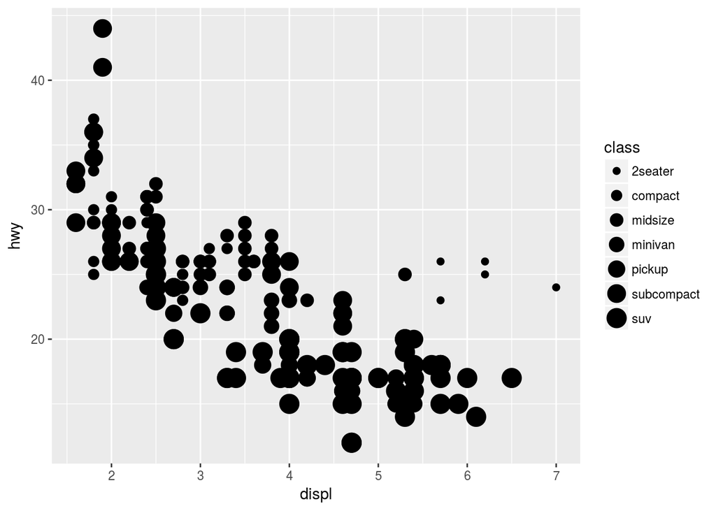

```r
library(tidyverse)
ggplot(data = mpg) + geom_point(mapping = aes(x = displ, y = hwy, size = class))
```

*Este comando es sólo para mapear un desorden variable, si se mapea una estética en orden, nos lanzará una advertencia*

Para mapear la estética ordenada de los datos que tenemos en la gráfica, podemos hacerlo mapeando la clase de la estetica alpha, que controla la transparencia de los puntos o la forma de los puntos.

__ Estética alpha donde se controla la transparencia de los puntos__

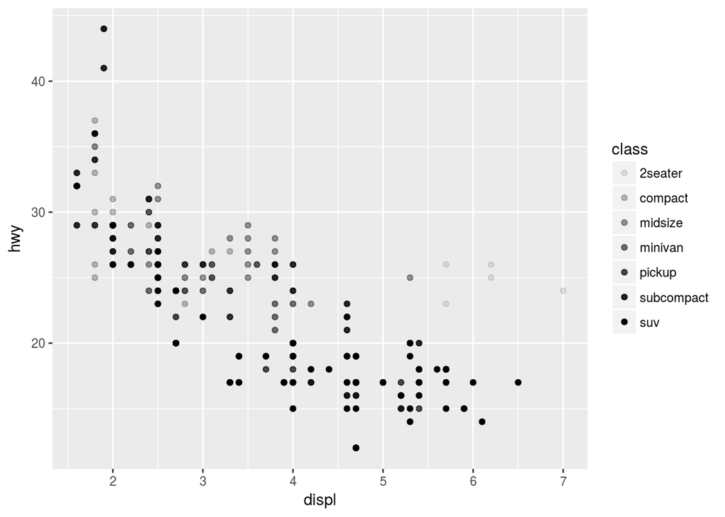

```r
library(tidyverse)
ggplot(data = mpg) + geom_point(mapping = aes(x = displ, y = hwy, alpha = class))
```

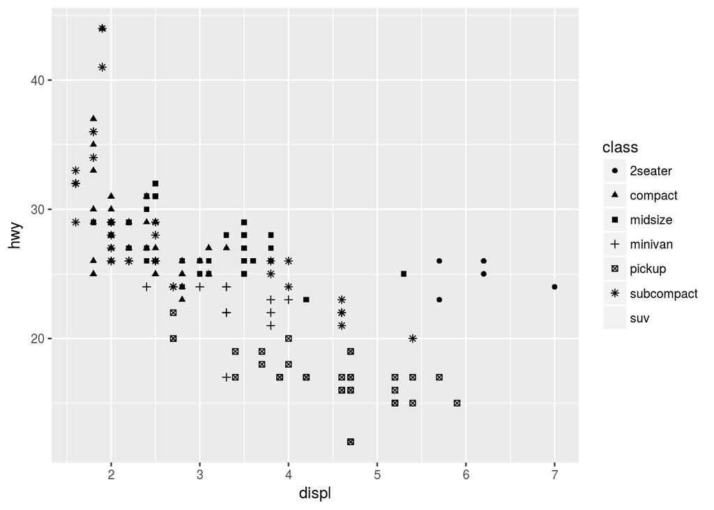

```r
library(tidyverse)
ggplot(data = mpg) + geom_point(mapping = aes(x = displ, y = hwy, shape = class))
```

Las estéticas tambien se pueden aplicar a todo el conjunto, sin que contengan información sobre la variable, y solo cambien la apariencia del gráfico, definindolas fuera de la funcion aes():

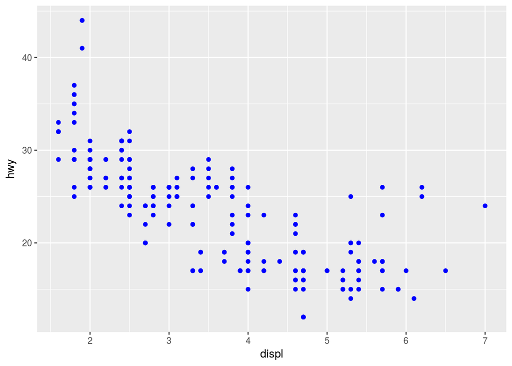

```r
library(tidyverse)
ggplot(data = mpg) + geom_point(mapping = aes(x = displ, y = hwy), color = "blue")
```

Aplica para: *Cambios de color* Tamaño de un punto en mm *la figura de un punto

Una vez que mapeas la estética, ggplot2 selecciona una escala razonable para mapearlo, y construye las leyendas que explican el mapeado entre valores y niveles. Para x y y crea un axis que marca y etiqueta.

## *Facetas*

Para analizar detalladamente las variables categoricas, es util dividir su gráfica en facetas, es decir, dividir la gráfica en subgráficas que muestran un subconjunto de datos.

Para facetear su gráfica con una sola variable, esto se logra con el comando:

> facet_wrap()

el argumento dentro de **facet_wrap** deberia ser una formula que crees con “~” seguido de un nombre de variable.

__*Aquí “formula” es el nombre de la estructura de datos en R,no es un sinonimo de ecuación)__

La variable que le pasas a **facet_wrap** debe ser discreto:

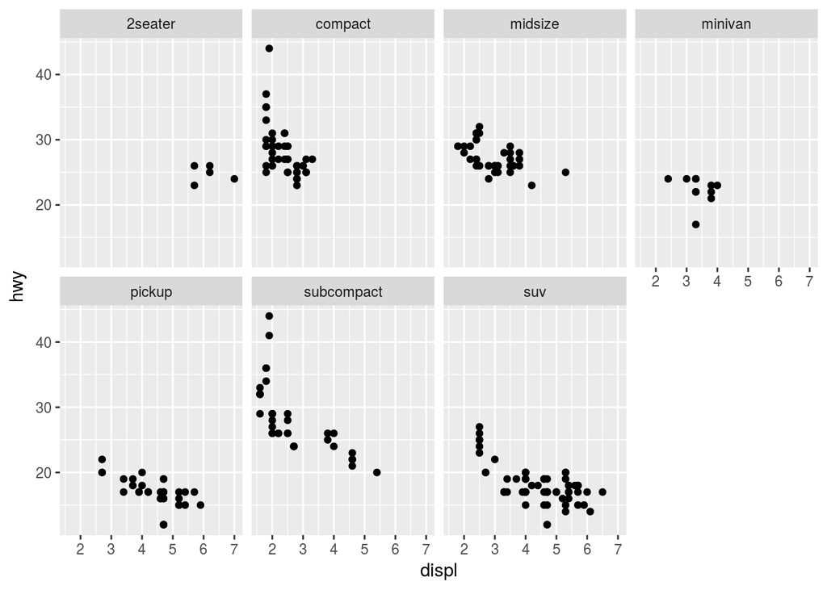

```r
library(tidyverse)
ggplot(data = mpg) + geom_point(mapping = aes(x = displ, y = hwy)) + facet_wrap(~ class, nrow = 2)
```

Ahora para facetear tu gráfica pero con dos variables, lo único que tenemos que hacer es agregar:

> facet_grid()

El primer argumento de **facet_grid** debe ser una formula, pero a diferencia de la enterior, ésta contendrá dos nombres de variables separados por “~”.

Ejemplo:

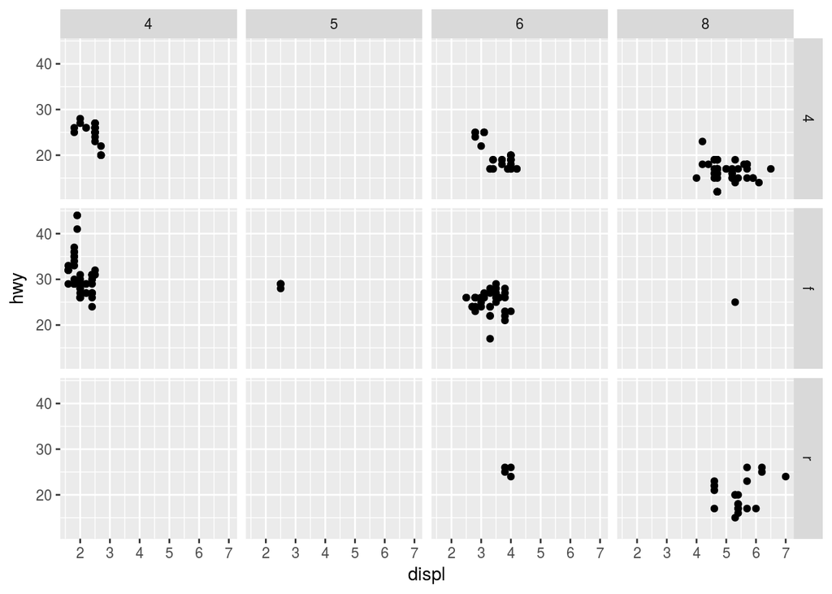

```r
library(tidyverse)
ggplot(data = mpg) + geom_point(mapping = aes(x = displ, y = hwy)) + facet_grid(drv ~ cyl)
```

Si no quiere facetear en filas y columnas, use a **“.”** En lugar de un nombre de variable, por ejemplo:

> - facet_grid(.~cyl)

### *Objetos Geométricos*

En qué se parecen las dos gráficas que acontinuación se precentan:

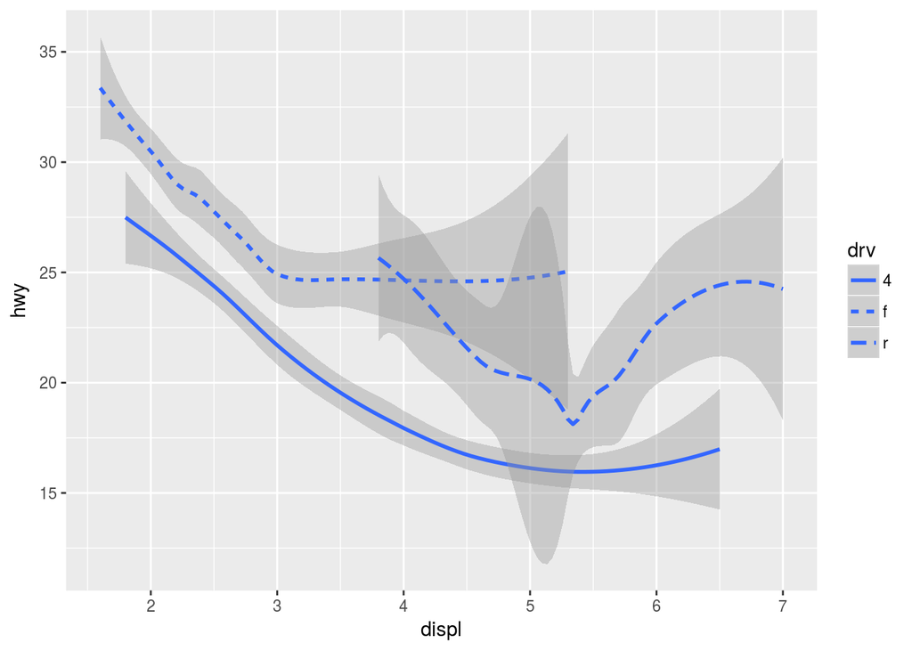

```r
library(tidyverse)
ggplot(data = mpg) + geom_smooth(mapping = aes(x = displ, y = hwy, linetype = drv))
```

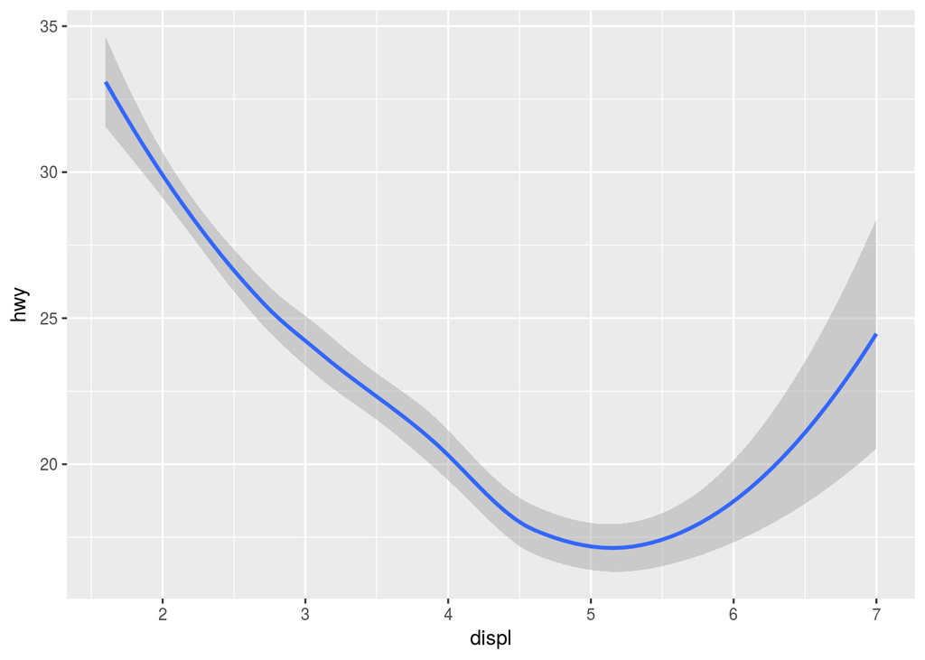

```r
library(tidyverse)
ggplot(data = mpg) + geom_smooth(mapping = aes(x = displ, y = hwy))
```

Ambas gráficas contienen a las mismas variables *“xy”* y la misma variable *“y”*, y ambas gráficas describen los mismos datos, pero visualmente las gráficas no representan los mismos datos. En la sintaxis de ggplot2, se dice que usan diferentes geoms.

> geom: Es un objeto geométrico que una gráfica utiliza para representar datos.

Las personas clasifican a las gráficas por el tipo de geom que utiliza, por ejemplo, las gráficas de barras(o histogramas), usan un geom de barra, las gráficas de linea, utilizan un geom de linea, etc.

Como se puede visualizar en las gráficas anteriores, la función geom in ggplot2 toma un argumento de mapeo. Sin envargo, no siempre se trabaja la estetica con geom. Puedes transformar la forma de un punto, pero no puedes transformar la forma de una linea, lo que puedes hacer en este caso es establecer el tipo de una linea. La funcion geom_smooth() se encarga de dibujar una linea diferente, para cada valor único de la variable que asigne al tipo de linea.

En la gráfica anterior, la función geom_smooth separa los autos en tres lineas basadas en su valor de dvr, que describe la transmision de un automovil.

Donde:

*Una linea describe todos los puntos con un valor de 4.* Otra describe todos los puntos con un valor de f. *La última linea describe todos los pntos con un valor r.

De los tres valores, 4 hace referencia a la tracción de las cuatro ruedas, f para la tracción frontal y r para la tracción tracera.

Puedes visualizar multiples geoms en una gráfica, agragando multiples funciones a ggplot().

Ejemplo:

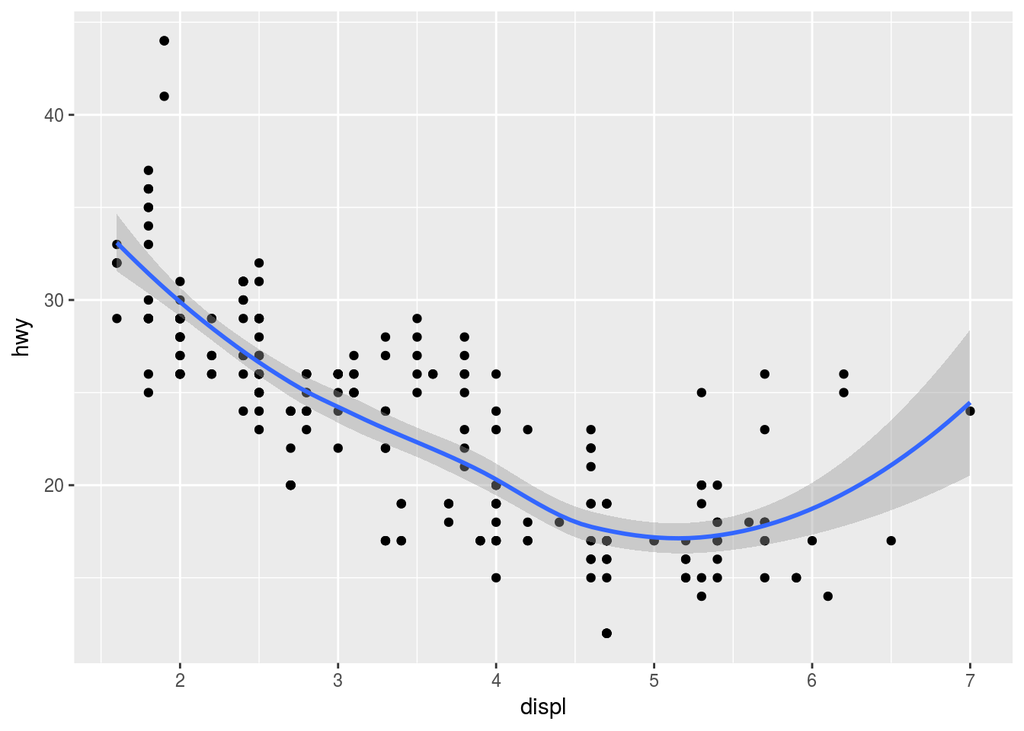

```r
library(tidyverse)
ggplot(data = mpg) + geom_point(mapping = aes(x = displ, y = hwy)) + geom_smooth(mapping = aes(x = displ, y = hwy))
```

Sin emvargo, el codigo anterior se nos duplica, para evitar ésta duplicación, pasamos un conjunto de asignaciones a ggplot(). ggplot2 tratará estos mapeos como mapeos globales que se aplican a cada geom en el gráfico.

Utilizará estas asignaciones para extender o sobrescribe las acciones globales solo para esa capa. Esto lo hace posible para mostrar diferenes estéticas en diferentes capas.

Ejemplo:

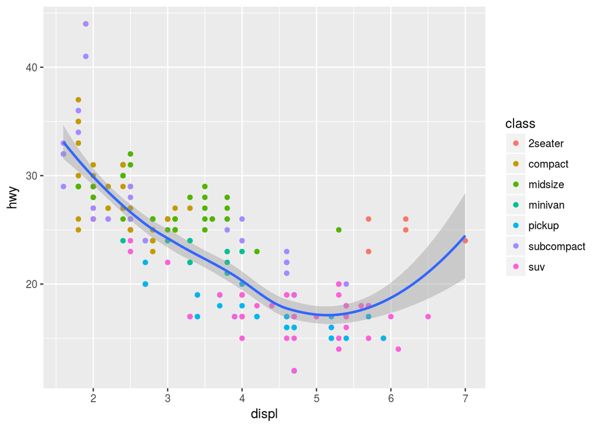

```r
library(tidyverse)

ggplot(data = mpg, mapping = aes(x = displ, y = hwy)) + geom_point(mapping = aes(color = class)) + geom_smooth()
```

Puede usar la misma idea para especificar datos diferentes para cada capa. Aquí, nuestra línea suave muestra solo un subconjunto del conjunto de datos de mpg,los vehículos subcompactos.

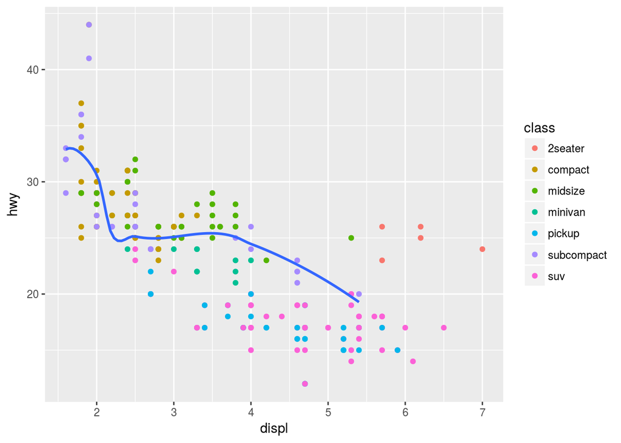

```r
library(tidyverse)

ggplot(data = mpg, mapping = aes(x = displ, y = hwy)) + geom_point(mapping = aes(color = class)) + geom_smooth(data = filter(mpg, class == "subcompact"),se = FALSE)
```

El argumento de datos locales en geom_smooth () anula el argumento de datos globales en ggplot () solo para esa capa.

ggplot(data = mpg, mapping = aes(x = displ, y = hwy, mapping = drv)) + geom_point() + geom_smooth(se = FALSE)

### *Transformación Estática*

Acontinuación, se verá como hacer una gráfica de barras y que información nos aportan.

Para realizar una gráfica de barras en ggplot2, usaremos el siguiente código:

```r
library(tidyverse)
ggplot(data = diamonds) + geom_bar(mapping = aes(x = cut))
```

[output not shown]

Recordemos que:

• Las gráficas de barras, los histogramas y los polígonos de frecuencia almacenan sus datos y luego grafica el numero de repeticiones de cada dato.

• Los suavizadores ajustan un modelo a sus datos y luego grafican predicciones del modelo.

El algoritmo utilizado para calcular nuevos valores para un gráfico se llama stat.

Generalmente puedes usar geoms y sets e intercambiarlas,por ejemplo, puedes recrear una gráfica anterior usando *stat_count()* en vez de geom_bar().

Ejemplo:

```r
library(tidyverse)
ggplot(data = diamonds) + geom_bar(mapping = aes(x = cut))
```

[output not shown]

para poderla recrear usando set, cambiamos geom_bar() por set_count():

```r
library(tidyverse)
ggplot(data = diamonds) + stat_count(mapping = aes(x = cut))
```

[output not shown]

Esto funciona porque cada geom tiene una estadística predeterminada, y cada estadística tiene un geom predeterminado. Esto significa que normalmente puede usar geoms sin preocuparse por la transformación estadística subyacente.

Hay tres razones por las que podría necesitar usar una estadística explícitamente:

La primera es para cambiar la estadistica predeterminada, en el siguiente código se cambia *geom_bar()* de conteo a la identidad, esto nos pemite modificar la altura de las barras de una altura ya asignada por la variable *y*.

Ahora veamos como modificar la altura de cada varra por cada valor en *y*:

*Primero tenemos que definir la altura de las barras, esto lo logramos con la tabla tribble asignando a la variable “a” la barra y a la variable “b” el tamaño de la barra.

Ejemplo:

```r
library(tidyverse)
demo <- tribble(
~a,      ~b,
"bar_1", 20,
"bar_2", 30,
"bar_3", 40
)
```

Despues solo la llamamos en la función ggplot:

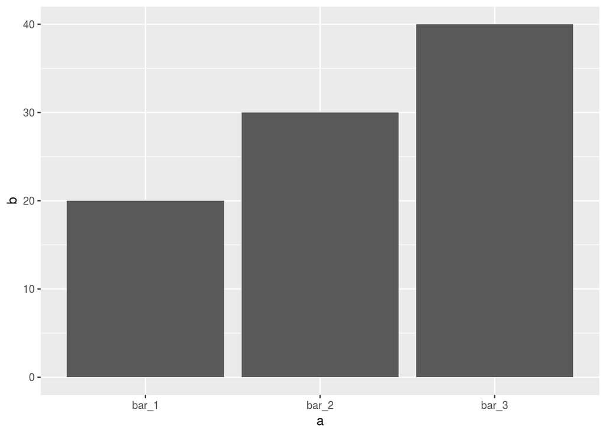

```r
library(tidyverse)
ggplot(data = demo) + geom_bar(mapping = aes(x = a, y = b), stat = "identity")
```

La segunda es si quisieramos modificar el mapeo por estáticas predeterminado (una de conteo por ejemplo) a una gráfica de barras de proporción:

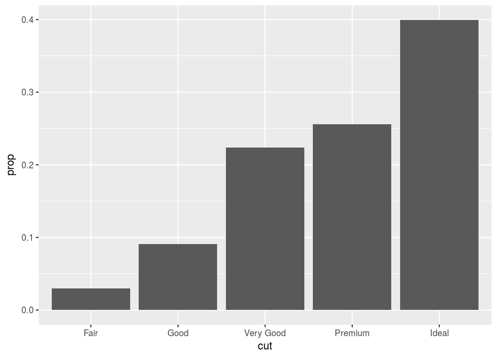

```r
library(tidyverse)
ggplot(data = diamonds) + geom_bar(mapping = aes(x = cut, y = ..prop.., group = 1))
```

La tercera la utilizaremos para resaltar las estádisticas de formación de tú código:

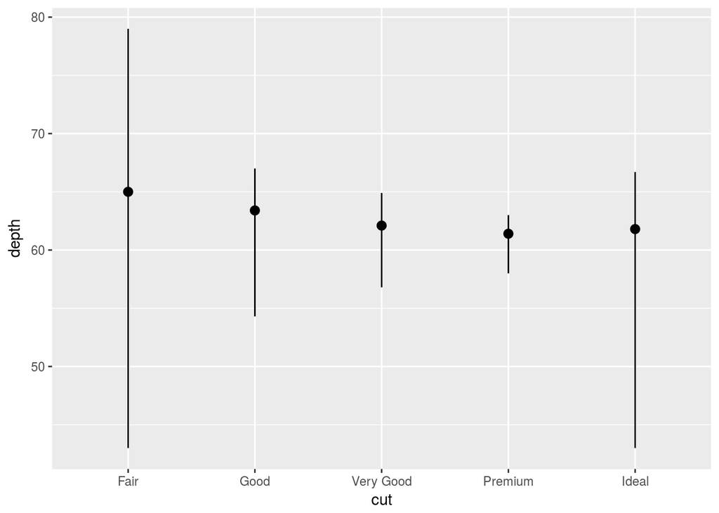

```r
library(tidyverse)
ggplot(data = diamonds) + stat_summary(mapping = aes(x = cut, y = depth), fun.ymin = min, fun.ymax = max, fun.y = median)
```

### *Ajustes de posición*

Se puede colorear una gráfica de barras usando tanto la estetica color o fill:

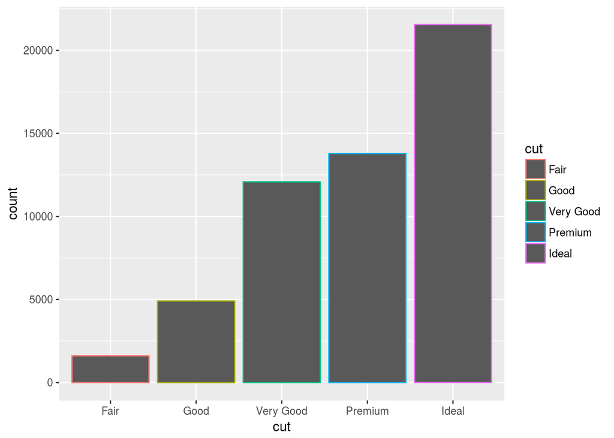

```r
library(tidyverse)
ggplot(data = diamonds) + geom_bar(mapping = aes(x = cut, color = cut))
```

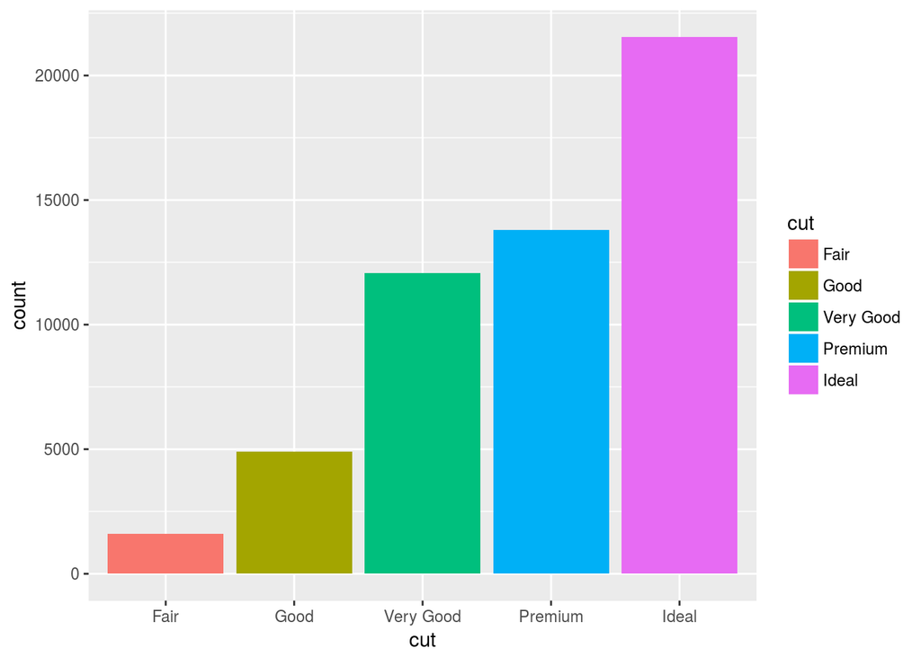

```r
library(tidyverse)
ggplot(data = diamonds) + geom_bar(mapping = aes(x = cut, fill = cut))
```

En caso de aplicar la estetica fill a alguna otra variable como clarity observaremos que se representará la variable con diferentes colores dentro de las barras, el cuales realizado automaticamente por el ajuste de posición especificado por el argumento position.

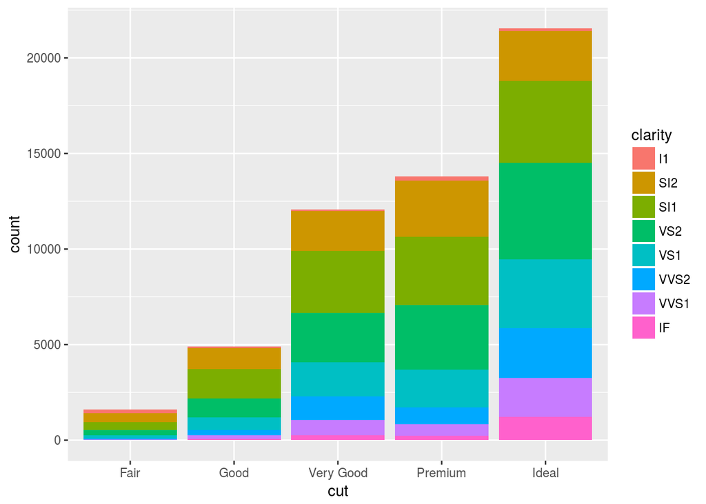

```r
library(tidyverse)
ggplot(data = diamonds) + geom_bar(mapping = aes(x = cut, fill = clarity))
```

Se tienen varias opciones para evitar que se arreglen de manera automática. position = “identity” pone cada objeto exactamente donde debe ir en el contexto del gráfico. La gran desventaja de usarlo en una gráfica de barras es que se colocan una sobre otra. Estos ajustes de posición en identidad es mas factible en geoms 2D, como los puntos, donde esta dado por default.

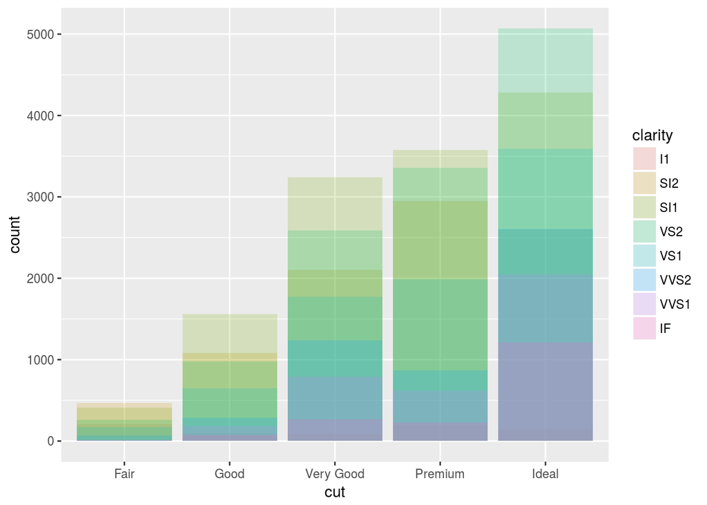

```r
library(tidyverse)
ggplot(data = diamonds, mapping = aes(x = cut, fill = clarity)) + geom_bar(alpha = 1/5, position = "identity")
```

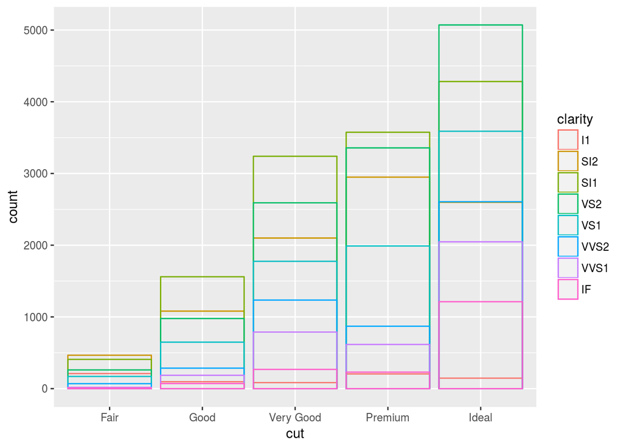

```r
library(tidyverse)
ggplot(data = diamonds, mapping = aes(x = cut, color = clarity)) + geom_bar(fill = NA, position = "identity")
```

Position = “fill” funciona como el apilamiento, pero hace cada set de barras de la misma altura, lo que lo hace ideal para comparar proporciones en grupos.

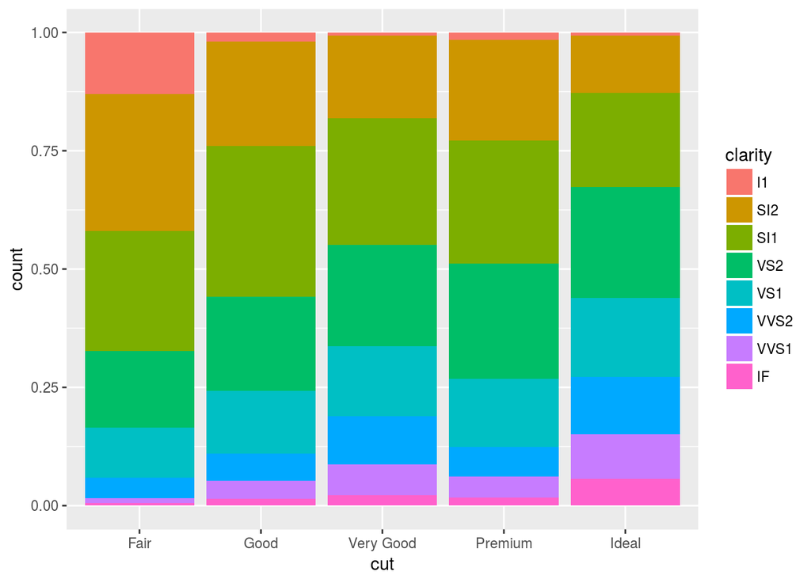

```r
library(tidyverse)
ggplot(data = diamonds) + geom_bar(mapping = aes(x = cut, fill = clarity), position = "fill")
```

position = “dodge” pone objetos que se traslapan directamente uno tras otro. Esto hace mas fácil comparar valores individuales:

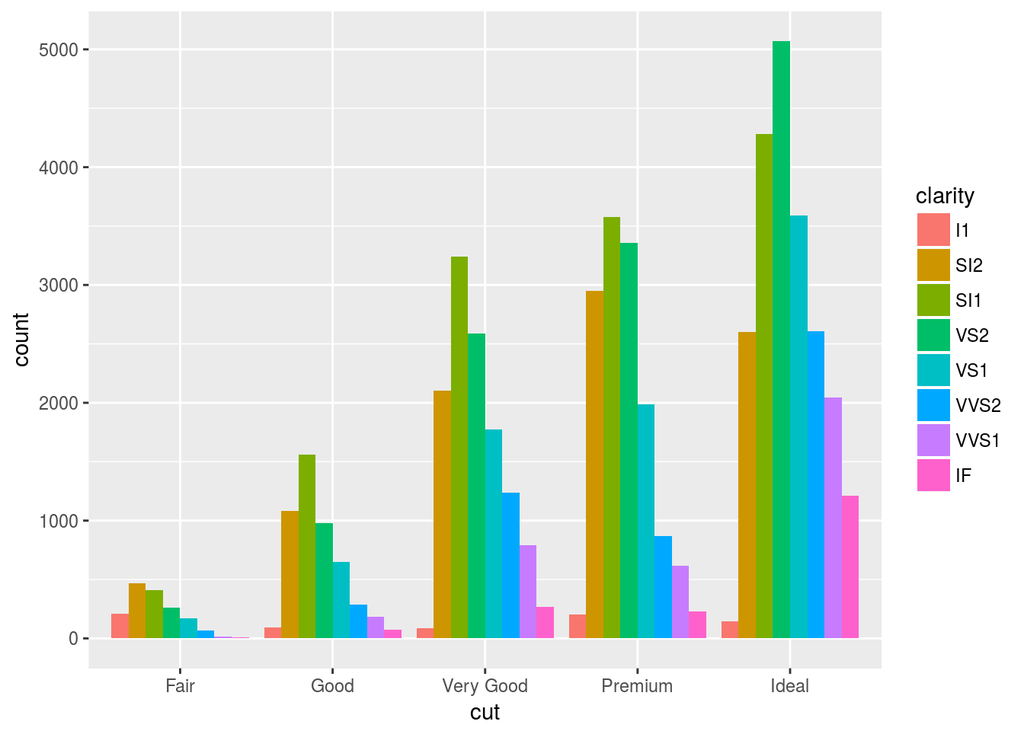

```r
library(tidyverse)
ggplot(data = diamonds) + geom_bar( mapping = aes(x = cut, fill = clarity), position = "dodge")
```

Hay otro tipo de ajuste que no es ideal para gráficas de barras, pero si para gráficas de puntos. Normalmente los puntos que estan expresados en una gráfica de puntos es un redondeo de los registros que se estan tomando en cuenta, y ademas no muestra el grueso de las muestras, dejandonos solo con los datos representatyivos, mas no el volumen. Esto se puede evitar usando el ajuste “Jitter”. position = “jitter” añade una pequeña cantidad de ruido aleatorio a cada punto. hace que cada punto este distribuido para que no existan mas de dos puntos con el mismo valor aleatorio.

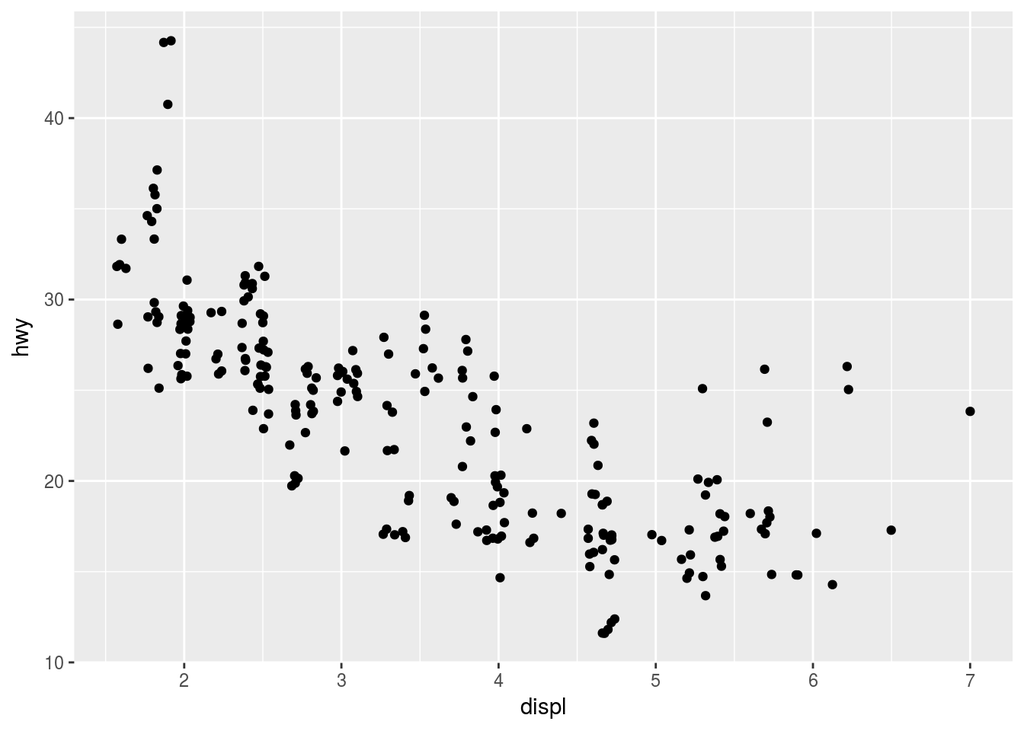

```r
library(tidyverse)
ggplot(data = mpg) + geom_point(mapping = aes(x = displ, y = hwy), position = "jitter")
```

Añadiendo aleatoriedad hace que tus gráficas sean mas reveladores a una escala mas robusta.

### *Sistemas Coordinados*

Los sistemas coordinados probablemente sean la parte más complicada de ggplot2. El sistema coordinado carteciano esta por determinado, donde la posición de x y de y actuan de manera independiente que buscan la localización de cada punto. Son un número de otros sistemas coordinados ocacionalmente útil.

> **coord_flip() : cambia los ejes x e y. Esto es usado si quieres un diagrama de cajas horizontal.**

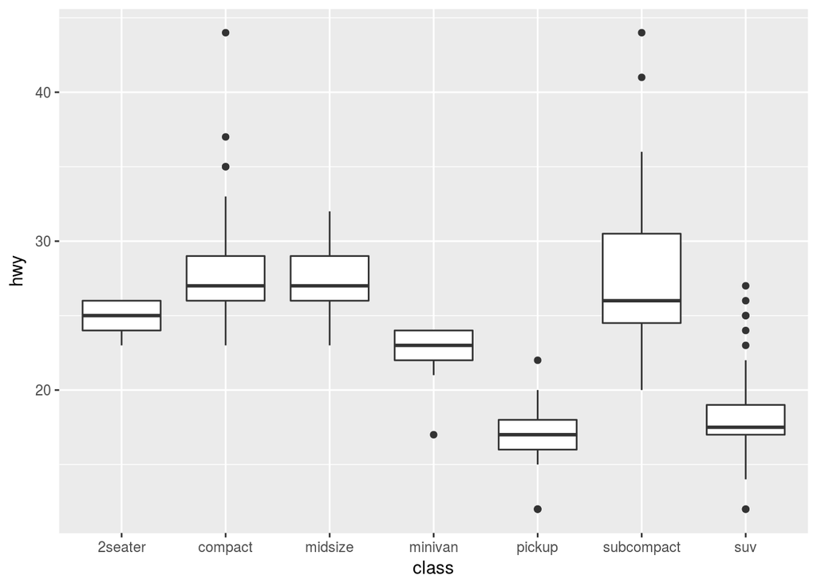

```r
library(tidyverse)
ggplot(data = mpg, mapping = aes(x = class, y = hwy)) + geom_boxplot()
```

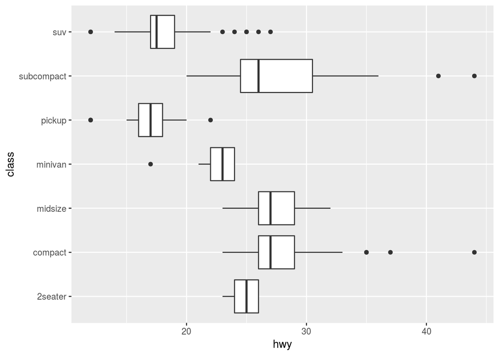

```r
library(tidyverse)
ggplot(data = mpg, mapping = aes(x = class, y = hwy)) + geom_boxplot() + coord_flip()
```

> **coord_quickmap() : establece la relación de aspecto correctamente para los mapas.**

*Es importante si trazas datos espaciales con ggplot2*

Ejemplo:

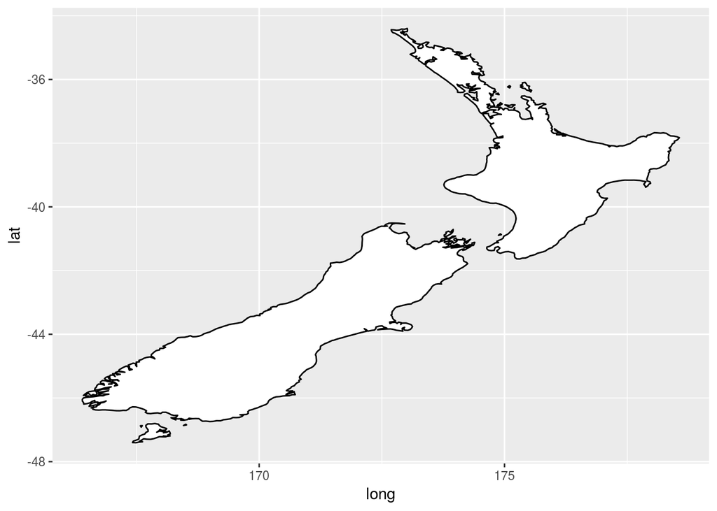

```r
library(tidyverse)
nz <- map_data("nz")
ggplot(nz, aes(long, lat, group = group)) + geom_polygon(fill = "white", color ="black")
```

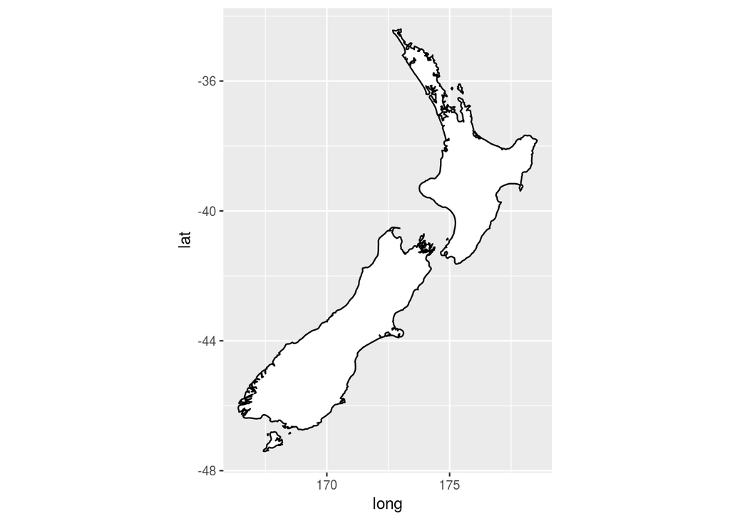

```r
library(tidyverse)
ggplot(nz, aes(long, lat, group = group)) + geom_polygon(fill = "white", color ="black") + coord_quickmap()
```

> **coord_polar : usado para las coordenadas polares.**

Las coordenadas polares revelan una interconexión sobre una gráfica de barras y una gráfica coxcomb.

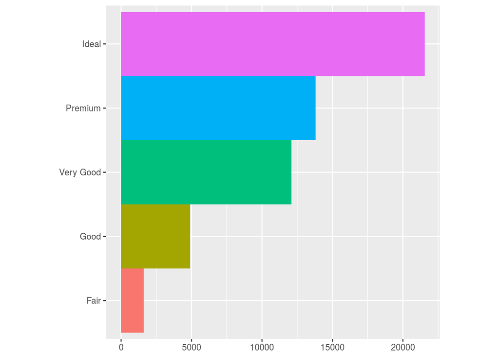

```r
library(tidyverse)
bar <- ggplot(data = diamonds) + geom_bar(mapping = aes(x = cut, fill = cut), show.legend = FALSE, width = 1) + theme(aspect.ratio = 1) + labs(x = NULL, y = NULL)
bar + coord_flip()
```

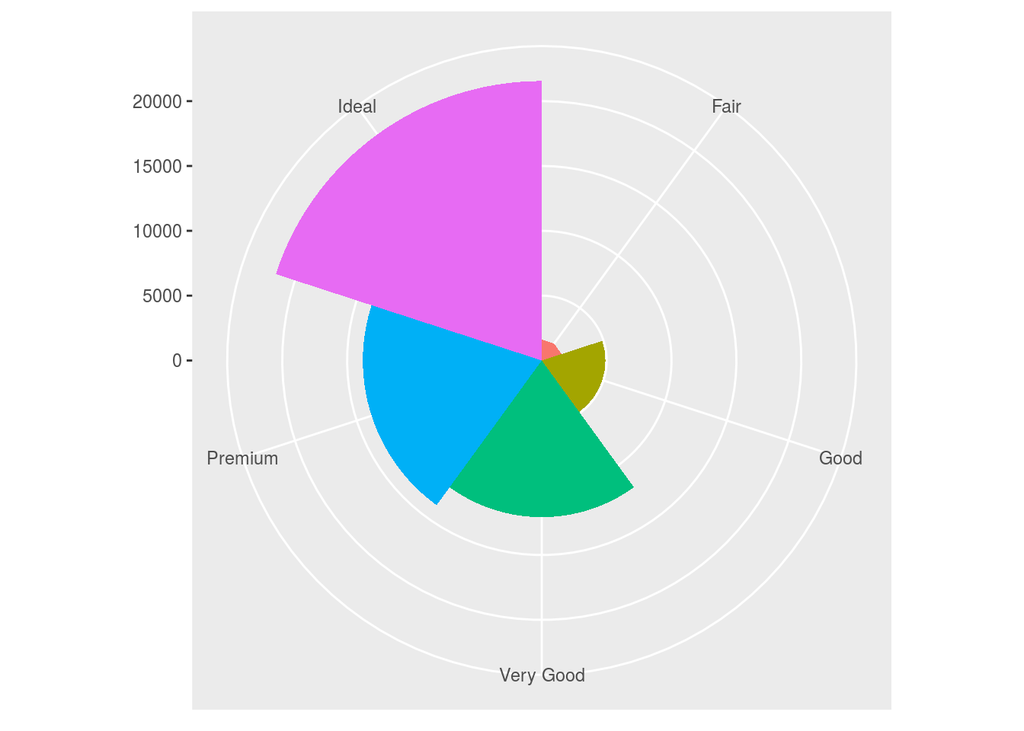

```r
bar + coord_polar()
```

Es posible convertir una gráfica de barras apiladas a una gráfica de pastel de la siguiente forma:

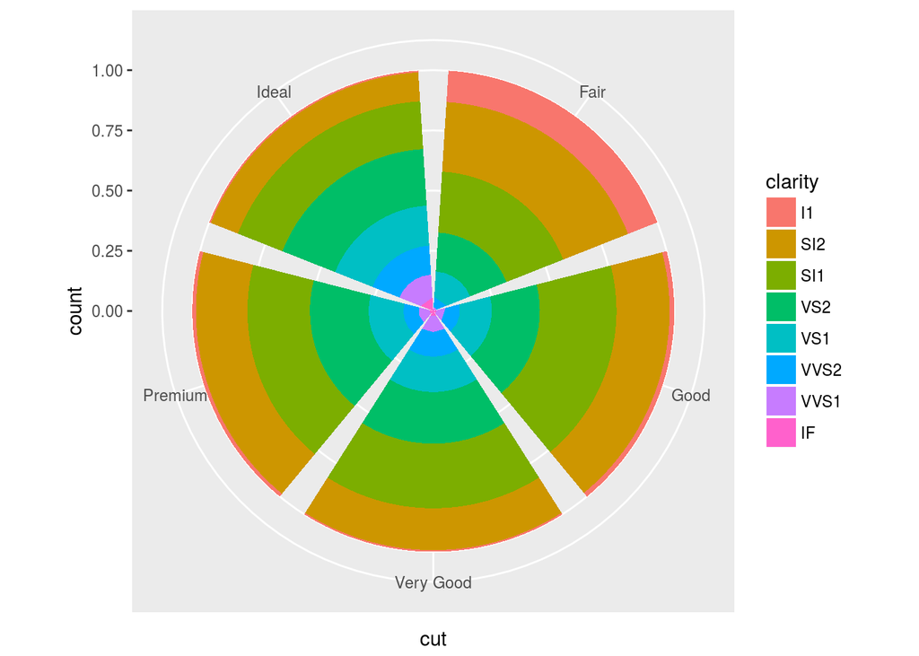

```r
library(tidyverse)
ggplot(data = diamonds) + geom_bar(mapping = aes(x = cut, fill = clarity), position = "fill") + coord_polar()
```

>**labs() Permite manipular las etiquetas de todos los datos para mostrar los nombres completos o añadir subtitulos para explicar datos.